# Variables Aleatorias Discretas y Continuas

Santiago Alférez (adaptado del libro de referencia)

# Variables Aleatorias Discretas (VAD)

Una variable aleatoria discreta (VAD) toma valores en un conjunto contable.

## Función de densidad

Para una VAD X:

- $0 \leq f(x) \leq 1$
- $P(X = x) = f(x)$
- $\sum_{x_i} f(x_i) = 1$

Ejemplo: Lanzamiento de un dado justo

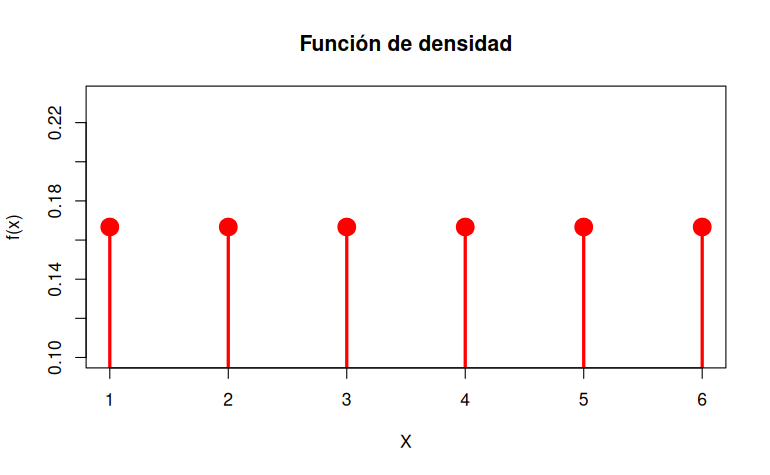

```r
x = 1:6
f = rep(1/6, 6)
plot(x, f, type="h", col="red", lwd=3, main="Función de densidad", xlab="X", ylab="f(x)")
points(x, f, col="red", lwd=10)
```

## Función de distribución

$F(x) = P(X \leq x) = \sum_{x_i \leq x} P(X = x_i)$

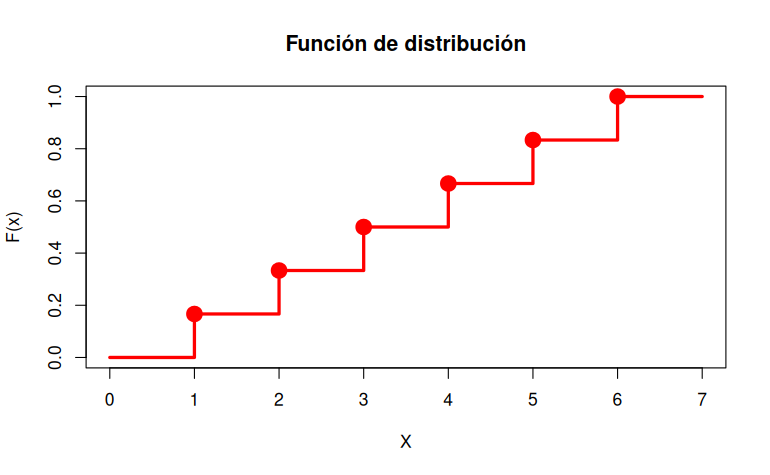

```r
F = cumsum(f)
plot(c(0,x,7), c(0,F,1), type="s", col="red", lwd=3, main="Función de distribución", xlab="X", ylab="F(x)")
points(x, F, col="red", lwd=8)
```

## Valor esperado y varianza

$E[X] = \sum_{i=1}^{k} x_i f(x_i)$

$Var(X) = E[X^2] - E[X]^2 = \sum_{i=1}^{k} x_i^2 f(x_i) - \mu^2$

```r
E_X = sum(x * f)
E_X2 = sum(x^2 * f)
Var_X = E_X2 - E_X^2
print(paste("Valor esperado (E[X]):", E_X))
```

```
[1] "Valor esperado (E[X]): 3.5"
```

```r
print(paste("Varianza (Var(X)):", Var_X))
```

```
[1] "Varianza (Var(X)): 2.91666666666667"
```

## Simulación

```r
set.seed(1)
sim_data = sample(x, 1000, replace=TRUE, prob=f)
hist(sim_data, breaks=seq(0.5,6.5,by=1), freq=FALSE, main="Simulación vs Teórica")
lines(x, f, type="h", col="red", lwd=3)
```

[figure not shown]

```r
points(x, f, col="red", lwd=10)
```

# Variables Aleatorias Continuas (VAC)

Una variable aleatoria continua (VAC) toma valores en un intervalo continuo.

## Función de densidad

Para una VAC X:

- $f(x) \geq 0$
- $\int_{-\infty}^{\infty} f(x) dx = 1$
- $P(a \leq X \leq b) = \int_{a}^{b} f(x) dx$

Ejemplo: $f(x) = \frac{1}{8} + \frac{3}{8}x$ para $0 \leq x \leq 2$

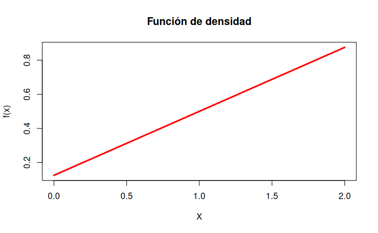

```r
x = seq(0, 2, 0.01)
f = 1/8 + 3/8*x
plot(x, f, type="l", col="red", lwd=3, main="Función de densidad", xlab="X", ylab="f(x)")
```

## Función de distribución

$F(x) = P(X \leq x) = \int_{-\infty}^{x} f(u) du$

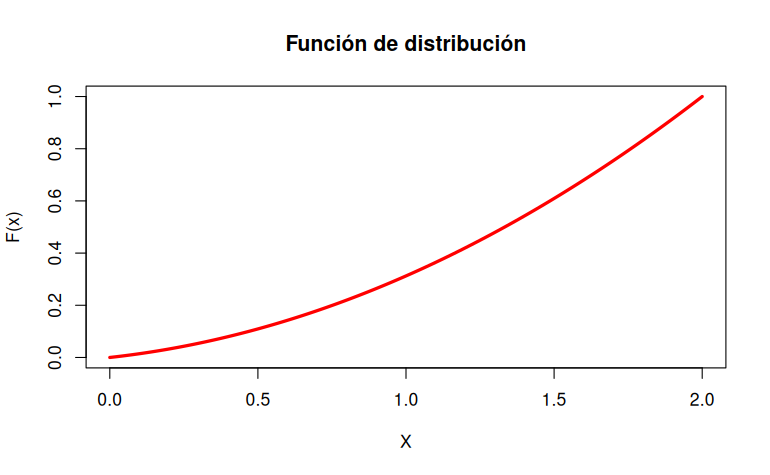

```r
F = 1/8*x + 3/16*x^2
plot(x, F, type="l", col="red", lwd=3, main="Función de distribución", xlab="X", ylab="F(x)")
```

## Valor esperado y varianza

Para una VAC, el valor esperado y la varianza se calculan mediante integrales:

$E[X] = \int_{-\infty}^{\infty} x f(x) dx$

$Var(X) = E[X^2] - E[X]^2 = \int_{-\infty}^{\infty} x^2 f(x) dx - E[X]^2$

Para nuestro ejemplo:

$E[X] = \int_{0}^{2} x (\frac{1}{8} + \frac{3}{8}x) dx = \frac{5}{4} = 1.25$

$Var(X) = \int_{0}^{2} x^2 (\frac{1}{8} + \frac{3}{8}x) dx - (\frac{5}{4})^2 = \frac{13}{48} \approx 0.2708$

## Simulación

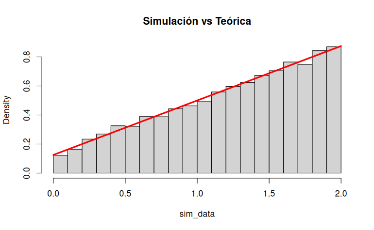

```r
set.seed(10)
x = seq(0, 2, 0.0001)
f = 1/8 + 3/8*x
sim_data = sample(x, 10000, replace=TRUE, prob=f)
hist(sim_data, freq=FALSE, main="Simulación vs Teórica")
lines(x, 1/8 + 3/8*x, col="red", lwd=3)
```

## Comparación entre media y varianza

```r
mean_sim = mean(sim_data)
var_sim = var(sim_data)
cat("Media teórica:", 1.25, "Media simulada:", mean_sim, "\n")
```

```
Media teórica: 1.25 Media simulada: 1.251668
```

```r
cat("Varianza teórica:", 13/48, "Varianza simulada:", var_sim, "\n")
```

```
Varianza teórica: 0.2708333 Varianza simulada: 0.2707881
```

La comparación entre los valores teóricos y simulados nos permite verificar la precisión de la simulación. Si los valores son cercanos, indica que la simulación representa adecuadamente la distribución teórica. Pequeñas diferencias son esperables debido a la naturaleza aleatoria de la simulación.